# Cyclistic_Casestudy

### Clean Data

Removing data where values are null, ride_length is 0 and started_at and ended_at values are same.

```r
NewDF[is.na(NewDF$ride_length),]
cleanDF <- NewDF[!is.na(NewDF$ride_length) & NewDF$started_at != NewDF$ended_at & NewDF$ride_length > 0,]
head(cleanDF)
```

```r
dim(cleanDF)[1] - sum(complete.cases(cleanDF))
```

```
## [1] 15163
```

```r
recleanedDF <- cleanDF[complete.cases(cleanDF), ]

dim(recleanedDF)[1] - sum(complete.cases(recleanedDF))
```

```
## [1] 0
```

```r
recleanedDF %>%
  as_tibble() %>%
  print(n=5)
```

```
## # A tibble: 1,682,388 × 12
##   ride_id          rideable_type started_at      trip_start_day ended_at
##   <chr>            <chr>         <chr>                    <dbl> <chr>
## 1 02668AD35674B983 docked_bike   5/27/2020 10:03              4 5/27/2020 10:16
## 2 7A50CCAF1EDDB28F docked_bike   5/25/2020 10:47              2 5/25/2020 11:05
## 3 2FFCDFDB91FE9A52 docked_bike   5/2/2020 14:11               7 5/2/2020 15:48
## 4 58991CF1DB75BA84 docked_bike   5/2/2020 16:25               7 5/2/2020 16:39
## 5 A79651EFECC268CD docked_bike   5/29/2020 12:49              6 5/29/2020 13:27
##   trip_end_day start_station_name         start_station_id
##          <dbl> <chr>                                 <dbl>
## 1            4 Franklin St & Jackson Blvd               36
## 2            2 Clark St & Wrightwood Ave               340
## 3            7 Kedzie Ave & Milwaukee Ave              260
## 4            7 Clarendon Ave & Leland Ave              251
## 5            6 Hermitage Ave & Polk St                 261
##   end_station_name               end_station_id member_casual ride_length
##   <chr>                                   <dbl> <chr>         <chr>
## 1 Wabash Ave & Grand Ave                    199 member        00:12:57
## 2 Clark St & Leland Ave                     326 casual        00:18:29
## 3 Kedzie Ave & Milwaukee Ave                260 casual        01:37:18
## 4 Lake Shore Dr & Wellington Ave            157 casual        00:13:52
## 5 Halsted St & Archer Ave                   206 member        00:37:17
## # ℹ 1,682,383 more rows
```

### Creating a new field ride_duration_minutes from ‘ride_length’ to make further analysis simpler.

```r
recleanedDF$ride_length <- hms(recleanedDF$ride_length )
recleanedDF$ride_length <- as.numeric(recleanedDF$ride_length, "seconds")
recleanedDF <- recleanedDF %>%
  mutate(ride_duration_minutes = ride_length / 60)
```

```r
colnames(recleanedDF)
```

```
##  [1] "ride_id"               "rideable_type"         "started_at"
##  [4] "trip_start_day"        "ended_at"              "trip_end_day"
##  [7] "start_station_name"    "start_station_id"      "end_station_name"
## [10] "end_station_id"        "member_casual"         "ride_length"
## [13] "ride_duration_minutes"
```

```r
head(recleanedDF)
```

```
## # A tibble: 6 × 13
##   ride_id          rideable_type started_at      trip_start_day ended_at
##   <chr>            <chr>         <chr>                    <dbl> <chr>
## 1 02668AD35674B983 docked_bike   5/27/2020 10:03              4 5/27/2020 10:16
## 2 7A50CCAF1EDDB28F docked_bike   5/25/2020 10:47              2 5/25/2020 11:05
## 3 2FFCDFDB91FE9A52 docked_bike   5/2/2020 14:11               7 5/2/2020 15:48
## 4 58991CF1DB75BA84 docked_bike   5/2/2020 16:25               7 5/2/2020 16:39
## 5 A79651EFECC268CD docked_bike   5/29/2020 12:49              6 5/29/2020 13:27
## 6 1466C5B39F68F746 docked_bike   5/29/2020 13:27              6 5/29/2020 14:14
##   trip_end_day start_station_name         start_station_id
##          <dbl> <chr>                                 <dbl>
## 1            4 Franklin St & Jackson Blvd               36
## 2            2 Clark St & Wrightwood Ave               340
## 3            7 Kedzie Ave & Milwaukee Ave              260
## 4            7 Clarendon Ave & Leland Ave              251
```

[output cut: 18 more lines]

### Creating a new column start_day_name

```r
recleanedDF$start_day_name <- recode(recleanedDF$trip_start_day,
       "1"="Sunday",
       "2"="Monday",
       "3"="Tuesday",
       "4"="Wednesday",
       "5"="Thursday",
       "6"="Friday",
       "7"="Saturday")
head(recleanedDF)
```

## Preferred bikes by different riders

```r
preferred_bike_df <- aggregate(ride_id  ~ rideable_type  + member_casual, data = recleanedDF, function(x) length(x))
preferred_bike_df
```

```
##   rideable_type member_casual ride_id
## 1   docked_bike        casual  764797
## 2 electric_bike        casual   21493
## 3   docked_bike        member  864547
## 4 electric_bike        member   31551
```

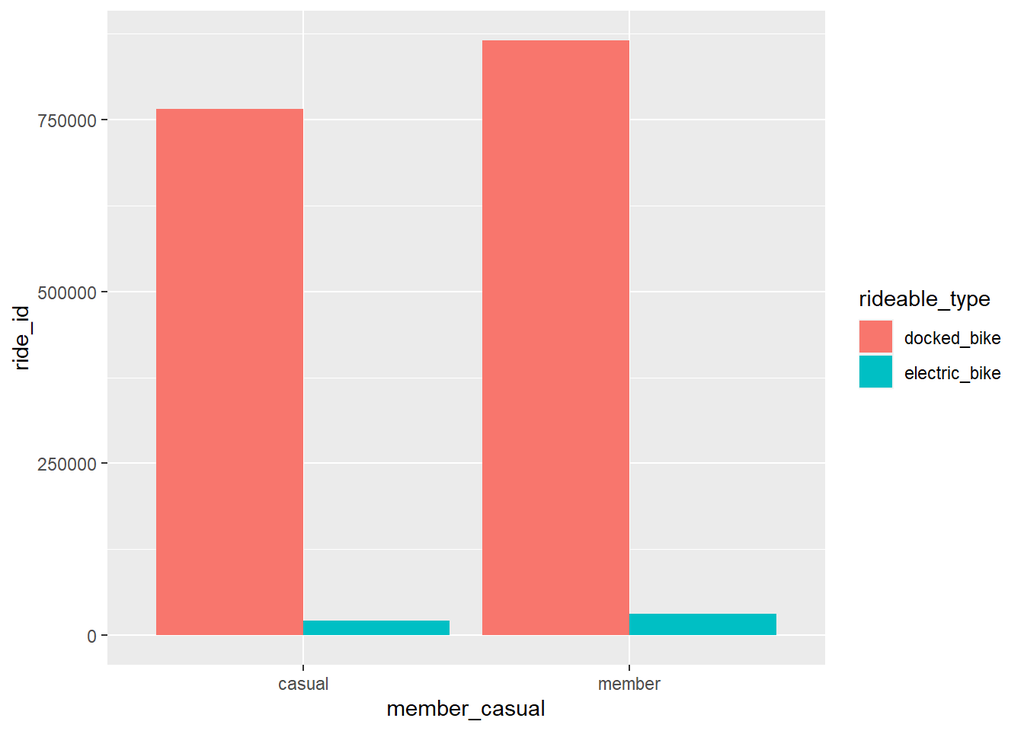

```r
ggplot(preferred_bike_df,aes(x = member_casual, y =ride_id, fill = rideable_type)) +
geom_bar(stat = "identity", position = "dodge")
```

## Both type of riders seem to prefer docked bikes rather than electric bikes.

## Number of rides on different days of a week by members and casual riders

```r
rides_daysofaweek_df <- aggregate(ride_id ~ start_day_name + member_casual + trip_start_day, data = recleanedDF, function(x) length(x))
rides_daysofaweek_df
```

```
##    start_day_name member_casual trip_start_day ride_id
## 1          Sunday        casual              1  145718
## 2          Sunday        member              1  122383
## 3          Monday        casual              2   80036
## 4          Monday        member              2  112394
## 5         Tuesday        casual              3   77830
## 6         Tuesday        member              3  115929
## 7       Wednesday        casual              4   83795
## 8       Wednesday        member              4  124858
## 9        Thursday        casual              5   94873
## 10       Thursday        member              5  130771
## 11         Friday        casual              6  118486
## 12         Friday        member              6  137417
## 13       Saturday        casual              7  185552
## 14       Saturday        member              7  152346
```

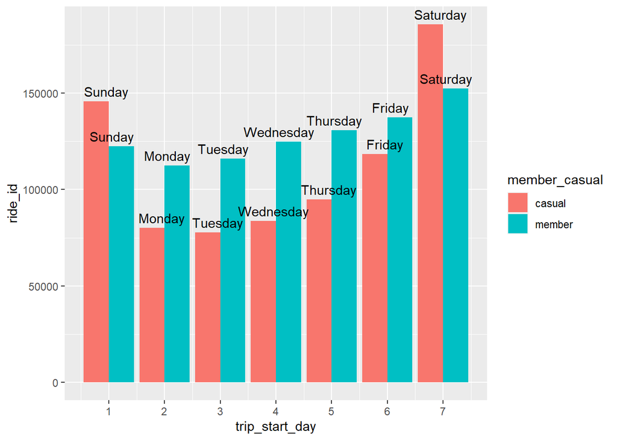

```r
ggplot(rides_daysofaweek_df, aes(x = trip_start_day, y = ride_id, fill = member_casual)) +
  geom_col(position = "dodge") + scale_x_continuous(breaks=seq(1,7,1)) + geom_text(aes(label=start_day_name), position=position_dodge(width=0.2), vjust=-0.5)
```

## Average ride time of different riders

```r
mean_rideduration_df <- recleanedDF %>%
  group_by(member_casual,trip_start_day,start_day_name) %>%
  summarise(mean_ride_duration=mean(ride_duration_minutes),
            .groups = 'drop') %>%
  as.data.frame()
mean_rideduration_df
```

```
##    member_casual trip_start_day start_day_name mean_ride_duration
## 1         casual              1         Sunday           46.51102
## 2         casual              2         Monday           42.34611
## 3         casual              3        Tuesday           40.25378
## 4         casual              4      Wednesday           39.17715
## 5         casual              5       Thursday           40.25927
## 6         casual              6         Friday           40.54787
## 7         casual              7       Saturday           44.29146
## 8         member              1         Sunday           19.26541
## 9         member              2         Monday           16.42958
## 10        member              3        Tuesday           16.50125
## 11        member              4      Wednesday           16.57196
## 12        member              5       Thursday           16.78459
## 13        member              6         Friday           17.03040
## 14        member              7       Saturday           19.16820
```

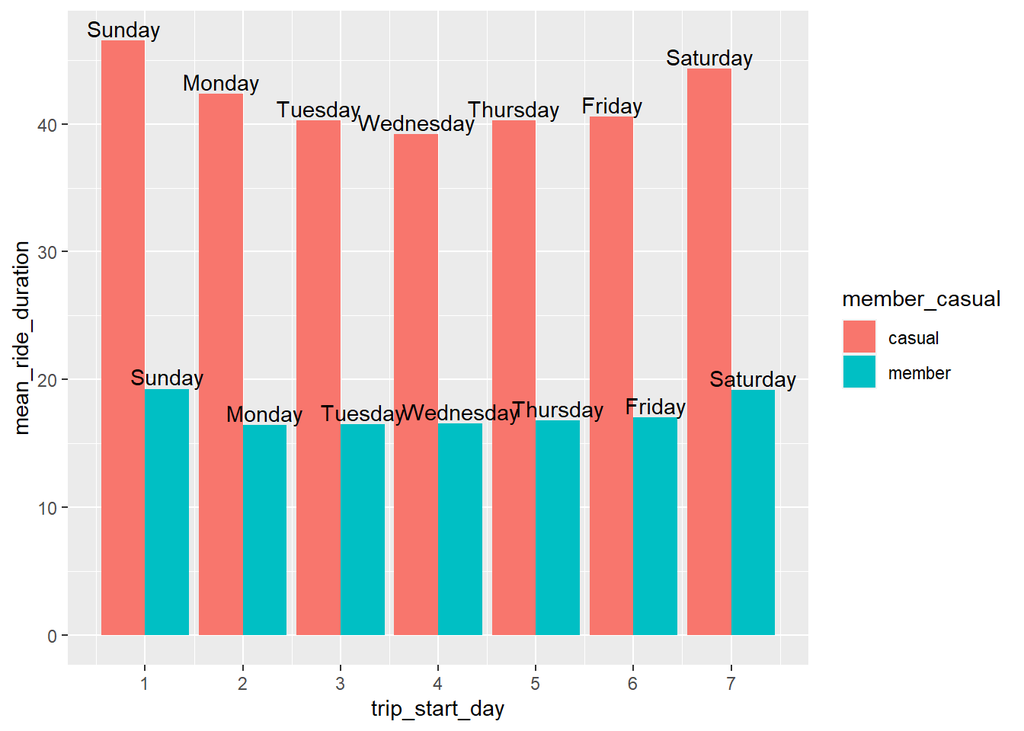

```r
ggplot(mean_rideduration_df, aes(x = trip_start_day, y = mean_ride_duration, fill = member_casual)) +
  geom_col(position = "dodge")  + scale_x_continuous(breaks=seq(1,7,1)) + geom_text(aes(label=start_day_name), position=position_dodge(width=0.9), vjust=-0.25)
```

## We can see average_ride_length of casual riders are always higher than members.

## Riders who return the bikes next day

```r
longer_rents_df <- recleanedDF %>%
  group_by(member_casual,trip_start_day,start_day_name ) %>%
  summarize(sum_rides=length(which(trip_end_day > trip_start_day)))
longer_rents_df
```

```
## # A tibble: 14 × 4
## # Groups:   member_casual, trip_start_day [14]
##    member_casual trip_start_day start_day_name sum_rides
##    <chr>                  <dbl> <chr>              <int>
##  1 casual                     1 Sunday              2515
##  2 casual                     2 Monday              1783
##  3 casual                     3 Tuesday             1588
##  4 casual                     4 Wednesday           1571
##  5 casual                     5 Thursday            2001
##  6 casual                     6 Friday              3743
##  7 casual                     7 Saturday               0
##  8 member                     1 Sunday               190
##  9 member                     2 Monday               185
## 10 member                     3 Tuesday              200
## 11 member                     4 Wednesday            235
## 12 member                     5 Thursday             301
## 13 member                     6 Friday               616
## 14 member                     7 Saturday               0
```

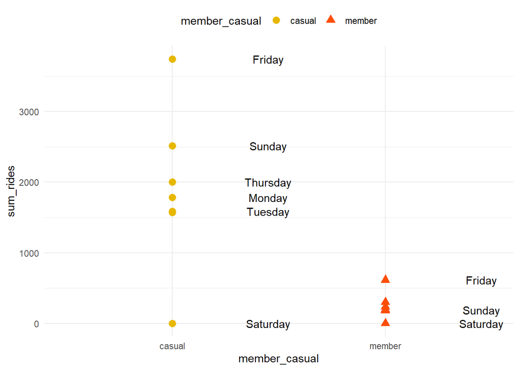

```r
ggplot(longer_rents_df, aes(member_casual, sum_rides)) +
  geom_point(aes(shape = member_casual, color = member_casual), size = 3) +
  scale_shape_manual(values = c(16, 17)) +
  scale_color_manual(values = c("#E7B800", "#FC4E07"))+
  theme_minimal() +
  theme(legend.position = "top") +
  geom_text(
    label=longer_rents_df$start_day_name,
    nudge_x=0.45, nudge_y=0.1,
    check_overlap=T
)
```

## Suggestions

1. Since casual riders rent more bikes on weekends, weekend changers can be increased for non members.
2. Average ride time of casual riders is always higher, so restriction of time can be placed for non members and charges can be increased for riders who borrow the bikes over time.
3. More Casual riders have a tendency to return the bike next day.So , perk time or points can be given to members who rent bikes for a longer time length or return the bike next day. It will create an opportunity for non members to buy membership.

## For future improvements

Data can be collected about the neighborhood of each bike rental station and the behavior of riders from different neighborhood can be analyzed.